# NOAA Weather Event Data: Analysis of Patterns

Alexa Albinson

2025-04-29

## Synopsis

This report explores the 2024 United States NOAA Storm Datasets, joining files with data pertaining to location, fatality, and event type. The primary focus on this analysis is to understand the impact of these severe weather events, particularly in respect to population health, location, and frequency. In better understanding the patters of severe weather, the United States government, and it’s people, can best prepare themselves for future events.

Through analysis, it became evident that excessive heat was the most harmful event in terms of fatalities, with a total of 4042 recorded in 2024. In addition, floods and thunderstorm winds were th most frequent events across states. In breaking the data up by month, it can be noted that various events peak across different months. Lastly, it was learned that the summer season, especially in May and July, weather events occur at a higher frequency.

This report provides valuable insights for government officials to prioritize resources for disaster preparedness and response. In order to best ensure the public’s safety, a coordinated response that has learned from past data and patterns is critical. The ability to plan ahead, by knowing which events are more likely in which months, could save precious resources.

## Data Processing

```r
# Load necessary libraries
library(dplyr)
library(readr)
# Define the folder path
folder_path <- "C:/Users/albin/OneDrive/Canisius/DAT 511"


# Define the file paths for the unzipped CSV files
details_file <- file.path(folder_path, "StormEvents_Details.csv")
fatalities_file <- file.path(folder_path, "StormEvents_Fatalities.csv")

locations_file <- file.path(folder_path, "StormEvents_Locations.csv")

file.exists("C:/Users/albin/OneDrive/Canisius/DAT 511/Events_Locations.csv")
```

```
## [1] FALSE
```

```r
# Load the CSV files into R
details <- read_csv(details_file)
fatalities <- read_csv(fatalities_file)
locations <- read_csv(locations_file)
# Join the datasets by EVENT_ID
joined_data <- details %>%
  left_join(locations, by = "EVENT_ID") %>%
  left_join(fatalities, by = "EVENT_ID")
# Save the joined data to a new CSV file
output_file <- file.path(folder_path, "StormEvents_joined_data.csv")
write_csv(joined_data, output_file)

# Inform the user
message("Joined data saved to: ", output_file)
```

```
## Joined data saved to: C:/Users/albin/OneDrive/Canisius/DAT 511/StormEvents_joined_data.csv
```

```r
# Optional: View the first few rows of the joined data
print(head(joined_data))
```

```
## # A tibble: 6 × 71
##   BEGIN_YEARMONTH BEGIN_DAY BEGIN_TIME END_YEARMONTH END_DAY END_TIME
##             <dbl>     <dbl>      <dbl>         <dbl>   <dbl>    <dbl>
## 1          202405        23       1947        202405      23     1947
## 2          202411        16        230        202411      18     1421
## 3          202405        19       1839        202405      19     1902
## 4          202405        23       2155        202405      23     2155
## 5          202405        24       1405        202405      24     1410
## 6          202411         1          0        202411       1     1600
## # ℹ 65 more variables: EPISODE_ID.x <dbl>, EVENT_ID <dbl>, STATE <chr>,
## #   STATE_FIPS <dbl>, YEAR <dbl>, MONTH_NAME <chr>, EVENT_TYPE <chr>,
## #   CZ_TYPE <chr>, CZ_FIPS <dbl>, CZ_NAME <chr>, WFO <chr>,
## #   BEGIN_DATE_TIME <chr>, CZ_TIMEZONE <chr>, END_DATE_TIME <chr>,
## #   INJURIES_DIRECT <dbl>, INJURIES_INDIRECT <dbl>, DEATHS_DIRECT <dbl>,
## #   DEATHS_INDIRECT <dbl>, DAMAGE_PROPERTY <chr>, DAMAGE_CROPS <chr>,
## #   SOURCE <chr>, MAGNITUDE <dbl>, MAGNITUDE_TYPE <chr>, FLOOD_CAUSE <chr>, …
```

## Results

```r
health_impact <- joined_data %>%
  group_by(EVENT_TYPE) %>%
  summarise(
    total_fatalities = sum(DEATHS_DIRECT, DEATHS_INDIRECT, na.rm = TRUE),
    total_injuries = sum(INJURIES_DIRECT, INJURIES_INDIRECT, na.rm = TRUE),
    total_harmed = total_fatalities + total_injuries
  ) %>%
  arrange(desc(total_harmed))

# Show top 10 most harmful event types
head(health_impact, 10)
```

| EVENT_TYPE | total_fatalities | total_injuries | total_harmed |
| --- | --- | --- | --- |
| Excessive Heat | 4042 | 100 | 4142 |
| Tornado | 235 | 1646 | 1881 |
| Flash Flood | 1422 | 68 | 1490 |
| Heat | 674 | 173 | 847 |
| Tropical Storm | 603 | 14 | 617 |
| Thunderstorm Wind | 119 | 172 | 291 |
| Winter Storm | 101 | 170 | 271 |
| Debris Flow | 193 | 24 | 217 |
| Hurricane | 37 | 162 | 199 |
| Flood | 192 | 0 | 192 |

# Excessive heat leads total fatalies and total harmed, with tornado and flash floods with the second and thirdest largest totals for individuals harmed.

```r
event_counts_by_state <- joined_data %>%
  group_by(STATE, EVENT_TYPE) %>%
  summarise(event_count = n(), .groups = 'drop') %>%
  arrange(desc(event_count))

# View top 10 most frequent event types by state
head(event_counts_by_state, 10)
```

| STATE | EVENT_TYPE | event_count |
| --- | --- | --- |
| TEXAS | Flash Flood | 1654 |
| TEXAS | Hail | 1613 |
| CALIFORNIA | Flood | 1268 |
| NORTH CAROLINA | Flash Flood | 1175 |
| KANSAS | Thunderstorm Wind | 1081 |
| PENNSYLVANIA | Thunderstorm Wind | 1039 |
| GEORGIA | Flash Flood | 1037 |
| NEW YORK | Thunderstorm Wind | 1036 |
| TEXAS | Thunderstorm Wind | 1020 |
| GEORGIA | Thunderstorm Wind | 1017 |

# Listed above are the top ten most frequent combinations of state and event type. One key takeaway is that Texas experienced the most flash floods and hail storms at 1654 and 1613, respectively.

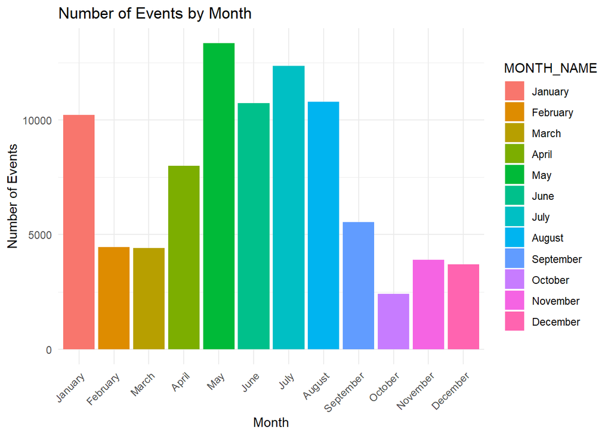

```r
library(dplyr)
library(ggplot2)

# Summarize the number of events by MONTH_NAME
events_by_month <- joined_data %>%
  group_by(MONTH_NAME) %>%
  summarise(event_count = n(), .groups = "drop")

# Ensure correct month ordering
month_levels <- c("January", "February", "March", "April", "May", "June",
                  "July", "August", "September", "October", "November", "December")
events_by_month$MONTH_NAME <- factor(events_by_month$MONTH_NAME, levels = month_levels)

# Bar graph of events by month
ggplot(events_by_month, aes(x = MONTH_NAME, y = event_count, fill = MONTH_NAME)) +
  geom_bar(stat = "identity") +
  labs(title = "Number of Events by Month", x = "Month", y = "Number of Events") +
  theme_minimal() +
  theme(axis.text.x = element_text(angle = 45, hjust = 1))
```

# The graph above represents each month’s total events. As shown, May experienced the greatest number, followed by July. In general, a peak can be seen during the summer season.

```r
# Load necessary libraries
library(dplyr)

# Group by month and event type, and calculate the count of each event type
event_month_summary <- joined_data %>%
  group_by(MONTH_NAME, EVENT_TYPE) %>%
  summarise(event_count = n(), .groups = 'drop') %>%
  arrange(MONTH_NAME, desc(event_count))

# For each month, select the event type with the highest count
most_common_event_per_month <- event_month_summary %>%
  group_by(MONTH_NAME) %>%
  slice_max(event_count, n = 1) %>%
  select(MONTH_NAME, EVENT_TYPE, event_count)

# Print the most common event for each month
print(most_common_event_per_month)
```

```
## # A tibble: 12 × 3
## # Groups:   MONTH_NAME [12]
##    MONTH_NAME EVENT_TYPE        event_count
##    <chr>      <chr>                   <int>
##  1 April      Flash Flood              1832
##  2 August     Thunderstorm Wind        3272
##  3 December   Winter Weather            581
##  4 February   Flood                     734
##  5 January    Winter Weather           1593
##  6 July       Thunderstorm Wind        4323
##  7 June       Thunderstorm Wind        3960
##  8 March      Hail                      849
##  9 May        Thunderstorm Wind        4755
## 10 November   Flash Flood               902
## 11 October    Drought                   612
## 12 September  Flash Flood              1911
```

# The figure above shows the event that occurred most commonly, per month. As one example, in the month of April, there were 1832 flash floods across the United States. This analysis is useful in understanding which types of events are most likely to occur, given the month.

```r
# Most common event -top 10
# Load necessary libraries
library(dplyr)

# Count the occurrences of each event type
event_type_summary <- joined_data %>%
  group_by(EVENT_TYPE) %>%
  summarise(event_count = n(), .groups = 'drop') %>%
  arrange(desc(event_count))

# Get the top 10 most common event types
top_10_event_types <- event_type_summary %>%
  slice_head(n = 10)

# Print the top 10 most common event types
print(top_10_event_types)
```

```
## # A tibble: 10 × 2
##    EVENT_TYPE        event_count
##    <chr>                   <int>
##  1 Thunderstorm Wind       20628
##  2 Flash Flood             15620
##  3 Hail                     9099
##  4 Flood                    8582
##  5 High Wind                3994
##  6 Drought                  3570
##  7 Winter Weather           3564
##  8 Tornado                  3248
##  9 Heat                     3202
## 10 Excessive Heat           2717
```

# The table above highlights which events happen most frequently across the United States. Using this data, government officials could better prepare resources, prioritizing events that occur more frequently and that require more consistent risk mitigation.